# Power Transformations

Nonlinear transformations are important part of feature preprocessing, expecially when features in a dataset have skewed distributions.

**Power transformations** are non-linear feature transformations that include raising to power.

Such transformations could be both expanding (removing left skewness) if power > 1 or collapsing (adding left skewness), if power < 1.

#### Box-Cox transformations

Box-Cox transformations (1964) is a parametrized family transformations. Parameter $\lambda$ controls the level of "expansion".

[figure not shown]

- $\lambda > 1$ - "expanding" transformation
- $\lambda = 1$ - linear transformation
- $\lambda < 1$ - "collapsing" transformation
- $\lambda \rightarrow 0$ - we switch to logarithmic class of transformation
- $\lambda < 0$ - "collapsing" transformation

Examples for 3 $\lambda$ values:

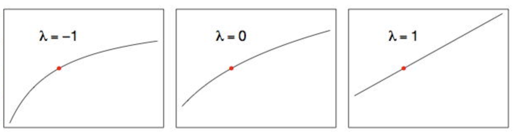

Why power transformation converges to logarithmic transformation when we move through $\lambda = 0$? To see it let's decompose the function into Taylor series:

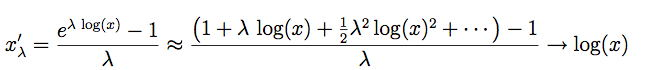

##### How to choose $\lambda$?

Usually $\lambda$ parameter is chosen that the response best fits the normal distribution.

So it's a maximum likelihood estimate.

##### Two parameter version

There is also a two parameter version of the transformation - here the second parameter (shift) is added.

[figure not shown]

##### Modern version

To be able to compare values among different lambdas we need to add a normalizer that restricts the variance to be the same:

[figure not shown]

and such normalizer is a geometric mean of values

[figure not shown]

### Yeo-Johnson transformations

Yeo-Johnson transformations (2000) is a modern modification that allows transformation to be applied to negative values.

[figure not shown]

### Sklearn implementation

sklearn.preprocessing.PowerTransfromer

There are two methods to choose from:

- Box-Cox transformation
- Yeo-Johnson transfortmation

Parameters cannot be controled, they are chosen as maximum likelihood estimates.